# PM566 Midterm Project

Amei Hao

10/8/2020

## Introduction

The project will build base on the crime data from 2020 to present provided by the Los Angeles Police Department. This dataset I looked up from LA city data, it reflects the occurrences of crime incidents in the City of Los Angeles going back to 2020. The main purposes we have: a) The association between the location where the most crime incidences happened(77th street) and victims’ age, sex and the different time slots of crimes. b) The distribution of the highest incidents of crime(AGGRAVATED ASSAULT) that happened in city Los Angeles.

## Methods

### EDA

We use EDA(Explortary Data Analysis) to import, check and clean our data.

```r
# Load the packages
library(data.table)
library(tidyverse)
```

```r
library(leaflet)
library(dplyr)
library(ggplot2)
```

1.Check the dimensions, headers, footers.

```r
# Read in the data
crime<-data.table::fread("/Users/amei/Downloads/Crime_Data_from_2020_to_Present.csv")
dim(crime)
```

```
## [1] 147947     28
```

```r
# head(crime)
# tail(crime) These outputs are too long here.
```

There are 147947 rows and 28 columns in the original crime 2020 to present dataset. We found that there are numerous observations in the dataset, so we decide to focus on the particular parts.

2. Next, let’s look into the variables that we care about more closely. Do a summary to see the quantiles, max, min for the numeric value.

```r
table(crime$`Vict Sex`)
```

```
##
##           F     H     M     X
## 18774 53413    13 63250 12497
```

```r
table(crime$`AREA NAME`)
```

```
##
## 77th Street     Central  Devonshire    Foothill      Harbor  Hollenbeck
##        9744        8765        5822        5296        6503        5873
##   Hollywood     Mission N Hollywood      Newton   Northeast     Olympic
##        7440        6306        7423        7617        6393        7177
##     Pacific     Rampart   Southeast   Southwest     Topanga    Van Nuys
##        8366        6679        8073        8363        6066        6530
##     West LA West Valley    Wilshire
##        6646        5975        6890
```

```r
summary(crime$`Vict Age`)
```

```
##    Min. 1st Qu.  Median    Mean 3rd Qu.    Max.
##    0.00   12.00   31.00   30.06   46.00  120.00
```

Then, we found that the crimes happened at 77th Street the most, it draws attention and I decided to build a new dataset to figure out the association between the location and victims’ age, sex and the time of crimes happens. And the victims’ age is kind of implausible since min=0, max=120, we’ll deal with the missing value and this kind of implausible values for the following steps.

```r
crime %>%
  count(`AREA NAME`, sort = TRUE)
```

```
## # A tibble: 21 x 2
##    `AREA NAME`     n
##    <chr>       <int>
##  1 77th Street  9744
##  2 Central      8765
##  3 Pacific      8366
##  4 Southwest    8363
##  5 Southeast    8073
##  6 Newton       7617
##  7 Hollywood    7440
##  8 N Hollywood  7423
##  9 Olympic      7177
## 10 Wilshire     6890
## # … with 11 more rows
```

```r
c77th <- crime[which(crime$'AREA NAME' == '77th Street')]
dim(c77th)
```

```
## [1] 9744   28
```

```r
# deal with the missing data in vict sex
sex_missing <- sum(c77th$`Vict Sex`=='') + sum(c77th$`Vict Sex`=='X') + sum(c77th$`Vict Sex`=='H')
sex_missing/length(c77th$`Vict Sex`)
```

```
## [1] 0.2272167
```

```r
# deal with the missing data in vict age
age_missing<- sum(c77th$`Vict Age`== 0) + sum(c77th$`Vict Age`=='')
age_missing/length(c77th$`Vict Age`)
```

```
## [1] 0.2348112
```

```r
# deal with the missing data in time
time_missing<-sum(c77th$`TIME OCC`=='')
time_missing/length(c77th$`TIME OCC`)
```

```
## [1] 0
```

22.7% of the data are missing or implausible in Vic Sex, and 23.5% of the data are missing or implausible in Vic Age. There is no time slot missing values.

```r
# Remove the missing values,unclear and implausible values we found in the previous step
c77 <- c77th[which(c77th$`Vict Sex` != '' & c77th$`Vict Sex` != 'X')]
c77 <- c77[which(c77$`Vict Age` != 0 & c77$`Vict Age` != '')]
```

For the numeric value, let’s take a look at its quantiles, min, max.

```r
summary(c77$`Vict Age`)
```

```
##    Min. 1st Qu.  Median    Mean 3rd Qu.    Max.
##     2.0    27.0    37.0    38.7    50.0    99.0
```

```r
c77<- c77[`Vict Age`>14 & `Vict Age`<70]
c77 <- c77[order(`Vict Age`)]
dim(c77)
```

```
## [1] 6998   28
```

## Preliminary Results

```r
c77$time<- cut(c77$`TIME OCC`,
               breaks=c(0, 600, 1200, 1800, 2400),
               labels=c("before dawn","moring","afternoon","night"),
               right = FALSE)
```

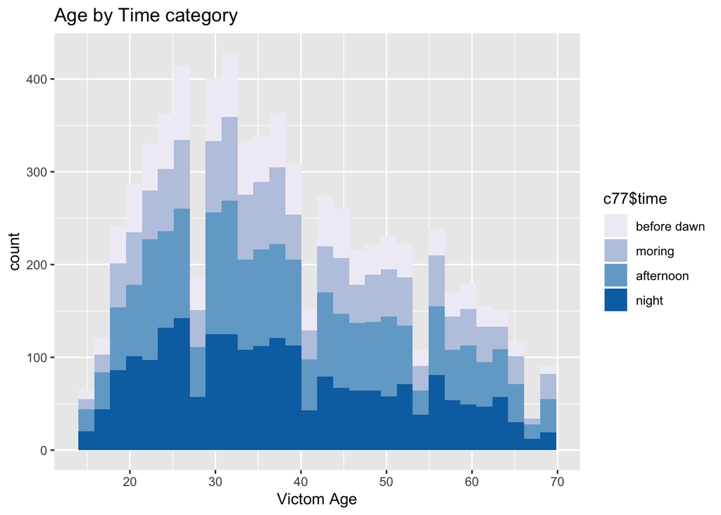

```r
# hist of Age by Time
 c77 %>%
  filter(!(c77$time %in% NA)) %>%
  ggplot()+ geom_histogram(mapping=aes(x=c77$`Vict Age`,fill=c77$time))+
  scale_fill_brewer(palette = "PuBu")+labs(title="Age by Time category", x="Victom Age", y="count")
```

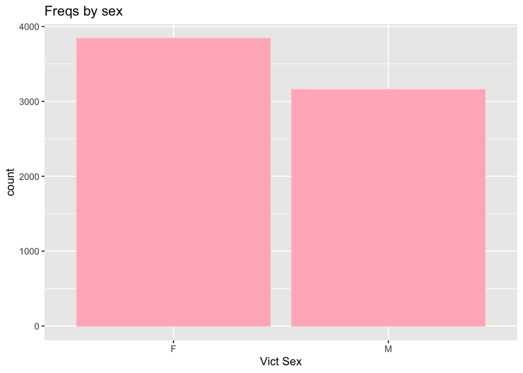

```r
# Barchart of Sex
ggplot(c77,aes(x =`Vict Sex`)) + geom_bar(stat = 'count', fill = 'lightpink', colour = 'pink') + labs(title = "Freqs by sex")
```

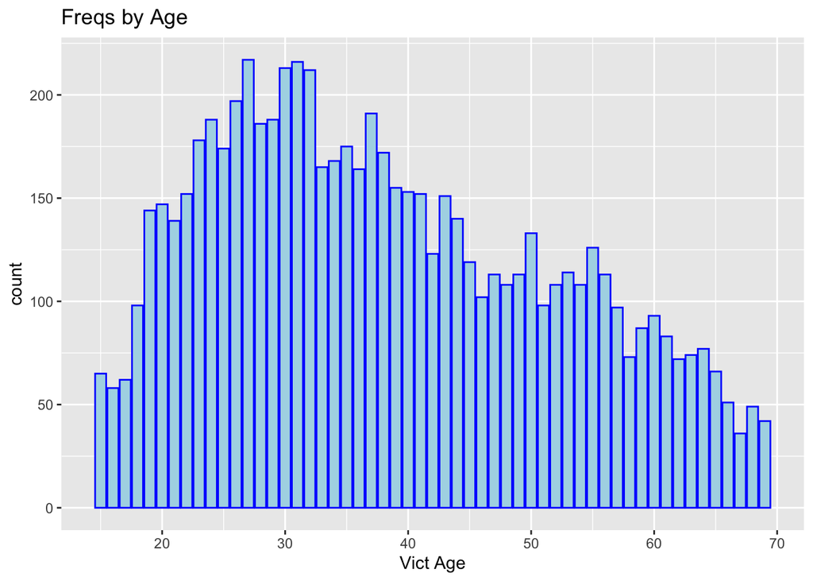

```r
# Barchart of Age
ggplot(c77,aes(x =`Vict Age`)) + geom_bar(stat = 'count', fill = 'lightblue', colour = 'blue') + labs(title = "Freqs by Age")
```

```r
c77%>%
  count(`Crm Cd Desc`, sort = TRUE)
```

```
## # A tibble: 85 x 2
##    `Crm Cd Desc`                                               n
##    <chr>                                                   <int>
##  1 ASSAULT WITH DEADLY WEAPON, AGGRAVATED ASSAULT           1015
##  2 INTIMATE PARTNER - SIMPLE ASSAULT                         761
##  3 BATTERY - SIMPLE ASSAULT                                  682
##  4 ROBBERY                                                   525
##  5 VANDALISM - FELONY ($400 & OVER, ALL CHURCH VANDALISMS)   471
##  6 BURGLARY FROM VEHICLE                                     369
##  7 VANDALISM - MISDEAMEANOR ($399 OR UNDER)                  354
##  8 INTIMATE PARTNER - AGGRAVATED ASSAULT                     276
##  9 CRIMINAL THREATS - NO WEAPON DISPLAYED                    253
## 10 THEFT PLAIN - PETTY ($950 & UNDER)                        248
## # … with 75 more rows
```

AGGRAVATED ASSAULT happened the most, we will take a look for other possible locations for this sever criminal insidents. A street map will show us where the crime incidents happened. First let’s get the unique latitutdes and longitudes and see how many criminal incidents there are.

```r
awd<- crime[which(crime$`Crm Cd Desc` == 'ASSAULT WITH DEADLY WEAPON, AGGRAVATED ASSAULT')]
c77_loc <- (unique(awd[,c("LAT","LON")]))
dim(c77_loc)
```

```
## [1] 5613    2
```

```r
leaflet(awd) %>%
  addProviderTiles('OpenStreetMap') %>%
  addCircles(lat=~LAT ,lng=~LON, radius=0.01)
```

[interactive chart not shown]